# Project_2

Navyasree Madhu

2024-11-28

# AR(1) with positive coefficients

```r
library(ggplot2)
set.seed(123)
# Function to plot AR(1) process
plot_ar1_process <- function(ar_coeffs, title_expression) {
  # Generate AR(1) process
  ar_process <- as.numeric(arima.sim(model = list(ar = ar_coeffs), n = 200))

  # Create data frame for plotting
  plot_data <- data.frame(Time = 1:200, AR_Oscillatory = ar_process)

  ggplot(plot_data, aes(x = Time, y = AR_Oscillatory)) +
    geom_line(color = "purple") +
    geom_point(color = "blue", size = 3, shape = 20) +
    labs(
      title = title_expression,
      x = "Time",
      y = "Value"
    ) +
    theme_minimal()
}
```

# Example-1 AR(1) with positive coefficients

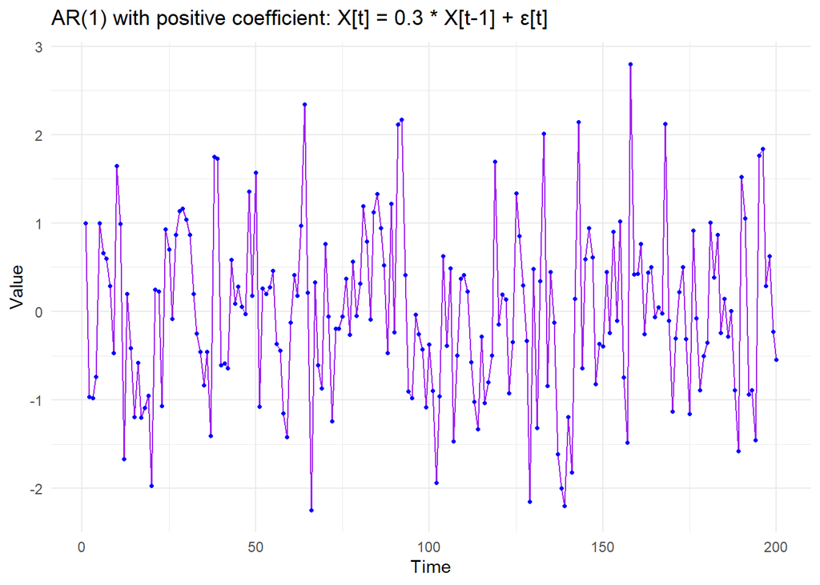

```r
set.seed(123)

pos_ar1_process <- function(ar_coeffs = 0.3,
                             title_expression = expression("AR(1) with positive coefficient: X[t] = 0.3 * X[t-1] + ε[t]")) {
  # Simulate AR(1) process
  ar_process <- as.numeric(arima.sim(model = list(ar = ar_coeffs), n = 200))

  # Create a data frame for plotting
  plot_data <- data.frame(Time = 1:200, AR_Oscillatory = ar_process)

  # Generate the plot using ggplot2
  ggplot(plot_data, aes(x = Time, y = AR_Oscillatory)) +
    geom_line(color = "purple") +
    geom_point(color = "blue", size = 1.5, shape = 20) +
    labs(
      title = title_expression,
      x = "Time",
      y = "Value"
    ) +
    theme_minimal()
}

pos_ar1_process()
```

#The Behavior of the Model

Low Coefficient (ϕ=0.3)

The value of ϕ=0.3 is relatively low, which means the influence of Xt−1 is moderate. The series will exhibit limited persistence; therefore, the deviations from the mean will fade quickly as the lagged influence diminishes over time.

Stationarity

The process is stationary because ∣ϕ∣<1. This implies that the time series will fluctuate around a constant mean (0 for this example). The variance of the series remains finite and does not grow over time.

White Noise Contribution

Random white noise (ϵt) plays a more significant role in shaping the series than lagged values. This results in a more stochastic (less deterministic) series.

Smoothness and Short-Term Correlation

The small ϕ value results in limited smoothness; Xt is only weakly correlated with Xt−1. Short-term trends are minimal, and the series appears more random.

Mean-Reverting Property

The series will revert to the mean quickly after a deviation because the influence of the lagged term diminishes rapidly.

# AR(1) with negative coefficients

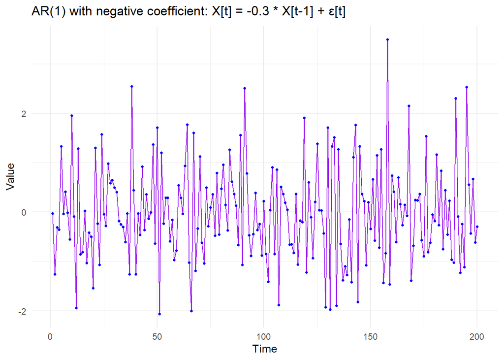

```r
set.seed(123)

neg_ar1_process <- function(ar_coeffs = -0.3,
                             title_expression = expression("AR(1) with negative coefficient: X[t] = -0.3 * X[t-1] + ε[t]")) {
  # Simulate AR(1) process
  ar_process <- as.numeric(arima.sim(model = list(ar = ar_coeffs), n = 200))

  # Create a data frame for plotting
  plot_data <- data.frame(Time = 1:200, AR_Oscillatory = ar_process)

  # Generate the plot using ggplot2
  ggplot(plot_data, aes(x = Time, y = AR_Oscillatory)) +
    geom_line(color = "purple") +
    geom_point(color = "blue", size = 1.5, shape = 20) +
    labs(
      title = title_expression,
      x = "Time",
      y = "Value"
    ) +
    theme_minimal()
}

neg_ar1_process()
```

The Behavior of the Model Low Negative Coefficient (ϕ=−0.3)

A small negative coefficient indicates: A weak negative correlation between Xt and Xt−1. Xt tends to move in the opposite direction to Xt−1 but with low persistence.

Oscillatory Behavior The negative coefficient introduces an alternating pattern: If Xt−1 is positive, Xt is more likely to be negative, and vice versa. However, the oscillations are not pronounced due to the small magnitude of ϕ.

Stationarity The process is stationary because ∣ϕ∣<1. This ensures the series fluctuates around a constant mean (0 for this example). The variance remains stable over time, preventing explosive growth or decay.

Randomness and White Noise Random white noise (ϵt) dominates the series: The weak ϕ value means that the current value is heavily influenced by random noise rather than the lagged term.

Limited Persistence The impact of deviations from the mean dissipates quickly because ∣ϕ∣ is small. The series lacks strong trends or long-term dependencies.

#Ar2 negative coefficient

[figure not shown]

```r
set.seed(123)

# Function to plot AR(2) process with negative coefficients
neg_ar2_process <- function(ar_coeffs = c(-0.1, -0.3),
                             title_expression = expression("AR(2) with negative coefficients: X[t] = -0.5 * X[t-1] - 0.3 * X[t-2] + ε[t]")) {
  # Generate AR(2) process
  ar_process <- as.numeric(arima.sim(model = list(ar = ar_coeffs), n = 200))

  # Create data frame for plotting
  plot_data <- data.frame(Time = 1:200, AR_Oscillatory = ar_process)

  # Generate the plot
  ggplot(plot_data, aes(x = Time, y = AR_Oscillatory)) +
    geom_line(color = "purple") +
    geom_point(color = "blue", size = 1.5, shape = 20) +
    labs(
      title = title_expression,
      x = "Time",
      y = "Value"
    ) +
    theme_minimal()
}

# Call the function to plot the AR(2) process
neg_ar2_process()
```

The Behavior of the Model

Negative Coefficients (ϕ1=−0.1, ϕ2=−0.3)

The negative coefficients imply that both Xt−1 and Xt−2 exert negative influences on Xt. Xt moves in the opposite direction of both Xt−1 and Xt−2. The degree of negative correlation is higher with Xt−2 (ϕ2=−0.3) than Xt−1 (ϕ1=−0.1).

Oscillatory Behavior

The presence of negative coefficients, especially for both lags, results in oscillations. If Xt−1 and Xt−2 have positive values, the current value Xt will be negative and vice versa. Due to the small size of the coefficients, the oscillations are relatively weak and less pronounced, but still observable.

Stationarity

The process remains stationary as long as the roots of the equation (based on the AR coefficients) lie outside the unit circle. In this case, the AR(2) model with ϕ1=−0.1 and ϕ2=−0.3 will be stationary since the magnitude of the coefficients is less than 1.

White Noise Contribution

The noise term ϵt is the reason for random variation in the series. This contribute to the stochastic nature of the process. Even with the negative autoregressive terms, random noise still largely influences the process.

Decay of Influence

Given that the coefficients are relatively small, the impact of past values on the current value decays over time, leading to weak persistence. This means that shocks or deviations from the mean will not last long, and the series will quickly revert back to the mean.

# AR(3) model with complex cycle

```r
set.seed(123)
# Function to plot AR(1) process
plot_ar3_process <- function(ar_coeffs, title_expression) {
  # Generate AR(1) process
  ar_process <- as.numeric(arima.sim(model = list(ar = ar_coeffs), n = 200))

  # Create data frame for plotting
  plot_data <- data.frame(Time = 1:200, AR_Oscillatory = ar_process)

  ggplot(plot_data, aes(x = Time, y = AR_Oscillatory)) +
    geom_line(color = "purple") +
    geom_point(color = "blue", size = 3, shape = 20) +
    labs(
      title = title_expression,
      x = "Time",
      y = "Value"
    ) +
    theme_minimal()
}
```

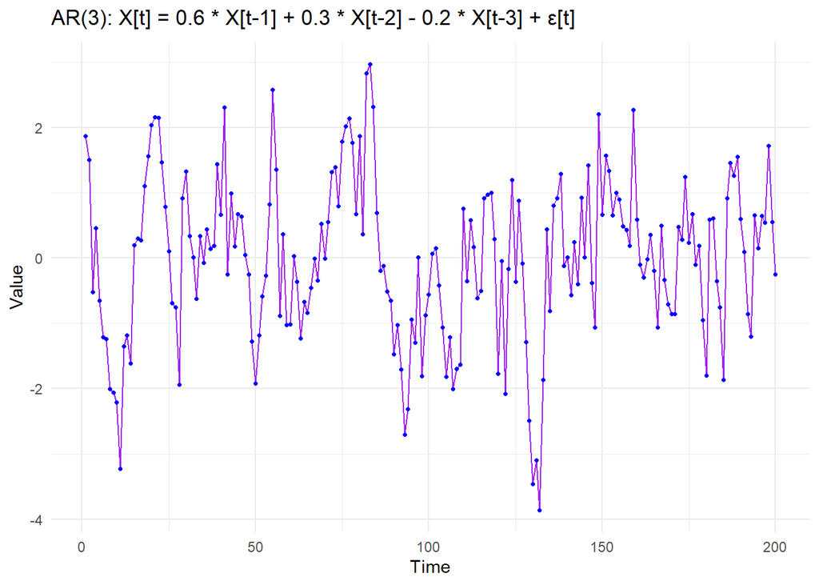

```r
set.seed(123)

# Function to plot AR(3) process
plot_ar3_process <- function(ar_coeffs = c(0.6, 0.3, -0.2),
                             title_expression = expression("AR(3): X[t] = 0.6 * X[t-1] + 0.3 * X[t-2] - 0.2 * X[t-3] + ε[t]")) {
  # Generate AR(3) process
  ar_process <- as.numeric(arima.sim(model = list(ar = ar_coeffs), n = 200))

  # Create data frame for plotting
  plot_data <- data.frame(Time = 1:200, AR_Oscillatory = ar_process)

  # Generate the plot
  ggplot(plot_data, aes(x = Time, y = AR_Oscillatory)) +
    geom_line(color = "purple") +
    geom_point(color = "blue", size = 1.5, shape = 20) +
    labs(
      title = title_expression,
      x = "Time",
      y = "Value"
    ) +
    theme_minimal()
}

# Call the function to plot the AR(3) process
plot_ar3_process()
```

#The Behavior of the Model Positive and Negative Coefficients

The AR(3) model has a combination of both positive and negative coefficients.

ϕ1=0.6: The current value Xt has a positive dependence on the previous value Xt−1, meaning that if Xt−1 is large, Xt will likely also be large.

ϕ2=0.3: The current value Xt has a moderate positive dependence on Xt−2 but is weaker than Xt−1.

ϕ3=−0.2: The current value Xt has a negative dependence on Xt−3, meaning that if Xt−3 is large, Xt will likely be smaller.

Oscillatory Behavior

The process exhibits oscillations when it has positive and negative coefficients. Positive coefficients contribute to values moving in the same direction, while negative coefficients introduce reversals. This can lead to a complex, oscillatory pattern, where the influence of earlier terms (both positive and negative) generates alternating cycles. The size of the coefficients determines the amplitude of these oscillations. Large positive coefficients (like ϕ1=0.6) cause the series to follow the previous term closely, while the negative coefficient ϕ3=−0.2 creates some counteracting force.

Stationarity

As long as the roots of the characteristic equation (derived from the AR coefficients) are outside the unit circle, the process is stationary. Given that the coefficients here are moderate in size, this process is stationary, meaning that the mean and variance will remain constant over time.

Impact of White Noise

The white noise term ϵt_tϵt adds randomness to the model, making the series unpredictable and variable. While the autoregressive terms provide structure, the random noise plays a major role in shaping the series, especially when the influence of past values is not very strong.

Persistence of Shocks

Because of the combination of positive and negative coefficients, shocks (deviations from the mean) may persist longer than in models with only one or two coefficients, as multiple lags influence the series. However, the persistence of shocks is still limited by the relatively small size of the negative coefficient (ϕ3=−0.2).